# Portfolios by Size

This Python program demonstrates how to create portfolios by size.

## Construction and Benchmarks

The codes below illustrate how to create portfolios by size. The first example is a case where securities are assigned to portfolios based on size (market capitalization = price * shares outstanding). Value weighted monthly returns are computed for each portfolio. This is the simplest program that uses all the universe of CRSP securities. It is shown basically as a guide since it includes not only common stocks but also other securities that are usually not included in standard academic portfolios such as ADRs and warrants.

These are basic programs on portfolio creation. The research applications have more complicated portfolio creation programs. An important one is the WRDS Research Application that replicates Fama-French factors. This application includes not only creating portfolios by size but also added Book-to-Market portfolios. It also addresses other important issues in portfolio construction such as (1) calculating market capitalization for firms that have more than one security at the same date, (2) using CRSP-Compustat merge product (and dealing with multiple matches at a given date), and (3) calculating a more precise weight when estimating value-weighted portfolio returns.

**Case 1 :****Size Portfolios for all CRSP Securities**

**Case 2 :****Size Portfolios for Common Stocks Using NYSE Breakpoints**

## Case 1. Size Portfolios for all CRSP Securities

This script has been developed to calculate size portfolios for all CRSP securities. Graphs comparing these calculated monthly value-weighted returns and CRSP portfolio returns are also available for review.

### Background

This script calculates size portfolios for all CRSP securities. It computes monthly value-weighted returns per each decile. Returns are weighted by the market capitalization of securities at the end of the previous month. Portfolios are created on December of the previous year. Finally, it compares the portfolio monthly returns (by decile) against CRSP decile returns.

```python
##########################################
# Size Portfolio for CRSP Securitie      #
# Sep 2019                               #
##########################################

import pandas as pd
import numpy as np
import datetime as dt
import wrds
from dateutil.relativedelta import *

###################
# Connect to WRDS #
###################
conn = wrds.Connection()

################################################
# Get CRSP Monthly Stocks for Decile Formation #
################################################
msf = conn.raw_sql("""
                      select a.permno, a.date,
                      a.ret, a.shrout, a.prc
                      from crsp.msf as a
                      where a.date >= '12/01/1999'
                      """, date_cols=['date'])

# keep only records with non missing ret prc and shrout value
msf = msf[(msf['prc'].notna()) & (msf['ret'].notna()) & (msf['shrout'].notna())]

msf['permno'] = msf['permno'].astype(int)
msf['size'] = msf['shrout'] * msf['prc'].abs()
msf['year'] = msf['date'].dt.year
msf['month'] = msf['date'].dt.month

# create msf_dec
msf_dec = msf[msf['month']==12][['date','permno','year','size']]

# create msf_ls
msf_ls = msf.sort_values(['permno', 'date'])
msf_ls['year_prev'] = msf_ls['year']-1
msf_ls['size_lag'] = msf_ls.groupby('permno')['size'].shift(1)
msf_ls['size_lag'] = np.where(msf_ls['size_lag'].isna(),\
 msf_ls['size']/(1+msf_ls['ret']), msf_ls['size_lag'])

#################################
# Compute Deciles for Each DEC  #
#################################
msf_dec = msf_dec.sort_values(['year'])
msf_dec['decile']=1+msf_dec.groupby('year')['size']\
.transform(lambda x: pd.qcut(x, 10, labels=False))

###################################
# Assign Size Group to All Months #
###################################
msf_groups = pd.merge(msf_ls[['permno','date','ret','size','size_lag','year_prev']], \
                      msf_dec[['permno','year','decile']], how='left', \
                      left_on=['permno','year_prev'], right_on=['permno','year'])

msf_groups=msf_groups[msf_groups['decile'].notna()]

#################################
# Compute Size Weighted Returns #
#################################
msf_groups = msf_groups.sort_values(['decile', 'date'])

# function to calculate value weighted return
def wavg(group, avg_name, weight_name):
    d = group[avg_name]
    w = group[weight_name]
    try:
        return (d * w).sum() / w.sum()
    except ZeroDivisionError:
        return np.nan

# value-weigthed return
vwrets=msf_groups.groupby(['decile','date']).apply(wavg, 'ret','size_lag')\
.to_frame().reset_index().rename(columns={0: 'vwret'})

##################################
# Compare Results with CRSP MSIX #
##################################
msix = conn.raw_sql("""
                      select caldt, decret1, decret2, decret3, decret4, decret5,
                      decret6, decret7, decret8, decret9, decret10
                      from crsp.msix where caldt >= '12/01/1999'
                      """, date_cols=['caldt'])

# transpose msix data
msix1=pd.melt(msix, id_vars='caldt', \
              value_vars=['decret1','decret2', 'decret3', 'decret4', 'decret5', 'decret6', \
'decret7', 'decret8','decret9','decret10'])

# extract decile information from decret
msix1['decile'] = msix1['variable'].str[6:].astype(int)
# rename return column
msix1 = msix1.rename(columns={'value':'decret', 'caldt':'date'})
msix1 = msix1.drop(['variable'], axis=1)

decile_returns = pd.merge(vwrets, msix1, how='left', on=['date','decile'])

###################
# End of Program  #
###################
```

```
Loading library list...
Done
```

[output not shown]

### Outcome Discussion

Each Permno that exists at December is in a Decile, e.g. in December 1999:

```python
msf_dec[msf_dec.date=="1999-12-31"].sort_values(['permno']).head(20)
```

|  | date | permno | year | size | decile |
| --- | --- | --- | --- | --- | --- |
| 0 | 1999-12-31 | 10001 | 1999 | 2.082500e+04 | 2.0 |
| 213 | 1999-12-31 | 10002 | 1999 | 9.419719e+04 | 5.0 |
| 373 | 1999-12-31 | 10009 | 1999 | 3.402825e+04 | 3.0 |
| 384 | 1999-12-31 | 10012 | 1999 | 1.547943e+05 | 6.0 |
| 453 | 1999-12-31 | 10016 | 1999 | 3.372774e+05 | 7.0 |
| 471 | 1999-12-31 | 10019 | 1999 | 8.277412e+04 | 4.0 |
| 502 | 1999-12-31 | 10025 | 1999 | 1.920950e+05 | 6.0 |
| 708 | 1999-12-31 | 10026 | 1999 | 1.848485e+05 | 6.0 |
| 937 | 1999-12-31 | 10028 | 1999 | 2.655000e+04 | 2.0 |
| 1166 | 1999-12-31 | 10032 | 1999 | 7.760720e+05 | 8.0 |
| 1395 | 1999-12-31 | 10035 | 1999 | 1.830279e+05 | 6.0 |
| 1444 | 1999-12-31 | 10037 | 1999 | 3.356438e+04 | 3.0 |
| 1498 | 1999-12-31 | 10039 | 1999 | 8.580600e+04 | 5.0 |
| 1517 | 1999-12-31 | 10042 | 1999 | 1.453031e+04 | 2.0 |
| 1617 | 1999-12-31 | 10044 | 1999 | 1.330875e+04 | 1.0 |
| 1846 | 1999-12-31 | 10051 | 1999 | 1.908400e+05 | 6.0 |
| 2075 | 1999-12-31 | 10056 | 1999 | 4.719000e+04 | 3.0 |
| 2158 | 1999-12-31 | 10065 | 1999 | 1.741122e+06 | 9.0 |
| 2387 | 1999-12-31 | 10066 | 1999 | 7.064500e+04 | 4.0 |
| 2423 | 1999-12-31 | 10078 | 1999 | 1.208881e+08 | 10.0 |

Each Permno, each month has a decile and a weight(the lag of size)

```python
msf_groups.sort_values(['permno','date']).head(50)
```

|  | permno | date | ret | size | size_lag | year_prev | year | decile |
| --- | --- | --- | --- | --- | --- | --- | --- | --- |
| 1 | 10001 | 2000-01-31 | -0.044118 | 19906.250000 | 20825.000000 | 1999 | 1999.0 | 2.0 |
| 2 | 10001 | 2000-02-29 | 0.015385 | 20212.500000 | 19906.250000 | 1999 | 1999.0 | 2.0 |
| 3 | 10001 | 2000-03-31 | -0.015758 | 19712.000000 | 20212.500000 | 1999 | 1999.0 | 2.0 |
| 4 | 10001 | 2000-04-28 | 0.011719 | 19943.000000 | 19712.000000 | 1999 | 1999.0 | 2.0 |
| 5 | 10001 | 2000-05-31 | -0.023166 | 19481.000000 | 19943.000000 | 1999 | 1999.0 | 2.0 |
| 6 | 10001 | 2000-06-30 | 0.027668 | 19800.000000 | 19481.000000 | 1999 | 1999.0 | 2.0 |
| 7 | 10001 | 2000-07-31 | -0.015625 | 19490.625000 | 19800.000000 | 1999 | 1999.0 | 2.0 |
| 8 | 10001 | 2000-08-31 | 0.047619 | 20418.750000 | 19490.625000 | 1999 | 1999.0 | 2.0 |
| 9 | 10001 | 2000-09-29 | 0.075758 | 21840.000000 | 20418.750000 | 1999 | 1999.0 | 2.0 |
| 10 | 10001 | 2000-10-31 | 0.028571 | 22464.000000 | 21840.000000 | 1999 | 1999.0 | 2.0 |
| 11 | 10001 | 2000-11-30 | 0.062500 | 23868.000000 | 22464.000000 | 1999 | 1999.0 | 2.0 |
| 12 | 10001 | 2000-12-29 | 0.032680 | 24355.500000 | 23868.000000 | 1999 | 1999.0 | 2.0 |
| 13 | 10001 | 2001-01-31 | 0.012821 | 24667.750000 | 24355.500000 | 2000 | 2000.0 | 3.0 |
| 14 | 10001 | 2001-02-28 | -0.012658 | 24414.000000 | 24667.750000 | 2000 | 2000.0 | 3.0 |
| 15 | 10001 | 2001-03-30 | 0.038462 | 25090.000000 | 24414.000000 | 2000 | 2000.0 | 3.0 |
| 16 | 10001 | 2001-04-30 | -0.025000 | 24462.750000 | 25090.000000 | 2000 | 2000.0 | 3.0 |
| 17 | 10001 | 2001-05-31 | 0.097436 | 26846.299521 | 24462.750000 | 2000 | 2000.0 | 3.0 |
| 18 | 10001 | 2001-06-29 | 0.114953 | 29653.400479 | 26846.299521 | 2000 | 2000.0 | 3.0 |
| 19 | 10001 | 2001-07-31 | 0.025424 | 30407.300959 | 29653.400479 | 2000 | 2000.0 | 3.0 |
| 20 | 10001 | 2001-08-31 | 0.020661 | 31035.550959 | 30407.300959 | 2000 | 2000.0 | 3.0 |
| 21 | 10001 | 2001-09-28 | -0.021862 | 30090.099520 | 31035.550959 | 2000 | 2000.0 | 3.0 |
| 22 | 10001 | 2001-10-31 | -0.033473 | 29082.900480 | 30090.099520 | 2000 | 2000.0 | 3.0 |
| 23 | 10001 | 2001-11-30 | -0.004329 | 29256.000000 | 29082.900480 | 2000 | 2000.0 | 3.0 |
| 24 | 10001 | 2001-12-31 | 0.006957 | 29380.699511 | 29256.000000 | 2000 | 2000.0 | 3.0 |
| 25 | 10001 | 2002-01-31 | -0.013100 | 28995.800489 | 29380.699511 | 2001 | 2001.0 | 3.0 |
| 26 | 10001 | 2002-02-28 | -0.053097 | 27488.299510 | 28995.800489 | 2001 | 2001.0 | 3.0 |
| 27 | 10001 | 2002-03-28 | -0.015888 | 26738.399019 | 27488.299510 | 2001 | 2001.0 | 3.0 |
| 28 | 10001 | 2002-04-30 | -0.043269 | 25581.449510 | 26738.399019 | 2001 | 2001.0 | 3.0 |
| 29 | 10001 | 2002-05-31 | 0.014824 | 25960.672108 | 25581.449510 | 2001 | 2001.0 | 3.0 |
| 30 | 10001 | 2002-06-28 | -0.024016 | 25019.280687 | 25960.672108 | 2001 | 2001.0 | 3.0 |
| 31 | 10001 | 2002-07-31 | -0.099794 | 22522.500000 | 25019.280687 | 2001 | 2001.0 | 3.0 |
| 32 | 10001 | 2002-08-30 | 0.017143 | 22908.599018 | 22522.500000 | 2001 | 2001.0 | 3.0 |
| 33 | 10001 | 2002-09-30 | -0.001685 | 22540.000000 | 22908.599018 | 2001 | 2001.0 | 3.0 |
| 34 | 10001 | 2002-10-31 | -0.019429 | 22187.879803 | 22540.000000 | 2001 | 2001.0 | 3.0 |
| 35 | 10001 | 2002-11-29 | -0.023893 | 21682.875000 | 22187.879803 | 2001 | 2001.0 | 3.0 |
| 36 | 10001 | 2002-12-31 | -0.106149 | 19046.440565 | 21682.875000 | 2001 | 2001.0 | 3.0 |
| 37 | 10001 | 2003-01-31 | 0.148143 | 21868.038913 | 19046.440565 | 2002 | 2002.0 | 2.0 |
| 38 | 10001 | 2003-02-28 | 0.035545 | 22645.339407 | 21868.038913 | 2002 | 2002.0 | 2.0 |
| 39 | 10001 | 2003-03-31 | -0.109268 | 19836.450247 | 22645.339407 | 2002 | 2002.0 | 2.0 |
| 40 | 10001 | 2003-04-30 | -0.324183 | 13405.810198 | 19836.450247 | 2002 | 2002.0 | 2.0 |
| 41 | 10001 | 2003-05-30 | 0.632495 | 21893.358912 | 13405.810198 | 2002 | 2002.0 | 2.0 |
| 42 | 10001 | 2003-06-30 | -0.287915 | 15595.950594 | 21893.358912 | 2002 | 2002.0 | 2.0 |
| 43 | 10001 | 2003-07-31 | 0.018303 | 15881.399703 | 15595.950594 | 2002 | 2002.0 | 2.0 |
| 44 | 10001 | 2003-08-29 | 0.086601 | 17256.750247 | 15881.399703 | 2002 | 2002.0 | 2.0 |
| 45 | 10001 | 2003-09-30 | 0.037594 | 17905.500247 | 17256.750247 | 2002 | 2002.0 | 2.0 |
| 46 | 10001 | 2003-10-31 | -0.130435 | 15570.000000 | 17905.500247 | 2002 | 2002.0 | 2.0 |
| 47 | 10001 | 2003-11-28 | -0.005000 | 15492.149456 | 15570.000000 | 2002 | 2002.0 | 2.0 |
| 48 | 10001 | 2003-12-31 | -0.003350 | 15446.199505 | 15492.149456 | 2002 | 2002.0 | 2.0 |
| 49 | 10001 | 2004-01-30 | 0.010084 | 15601.960594 | 15446.199505 | 2003 | 2003.0 | 1.0 |
| 50 | 10001 | 2004-02-27 | 0.079867 | 16848.039406 | 15601.960594 | 2003 | 2003.0 | 1.0 |

Size Weighted Returns

```python
vwrets.head(15)
```

|  | decile | date | vwret |
| --- | --- | --- | --- |
| 0 | 1.0 | 2000-01-31 | 0.222626 |
| 1 | 1.0 | 2000-02-29 | 0.246672 |
| 2 | 1.0 | 2000-03-31 | -0.024419 |
| 3 | 1.0 | 2000-04-28 | -0.175907 |
| 4 | 1.0 | 2000-05-31 | -0.093232 |
| 5 | 1.0 | 2000-06-30 | 0.051372 |
| 6 | 1.0 | 2000-07-31 | -0.031004 |
| 7 | 1.0 | 2000-08-31 | 0.054793 |
| 8 | 1.0 | 2000-09-29 | -0.041949 |
| 9 | 1.0 | 2000-10-31 | -0.104683 |
| 10 | 1.0 | 2000-11-30 | -0.127776 |
| 11 | 1.0 | 2000-12-29 | -0.077421 |
| 12 | 1.0 | 2001-01-31 | 0.535034 |
| 13 | 1.0 | 2001-02-28 | -0.130583 |
| 14 | 1.0 | 2001-03-30 | -0.115912 |

The figure below plots the comparison between vwrets calculated from the Python code against the decile returns obtained from CRSP.MSIX dataset.

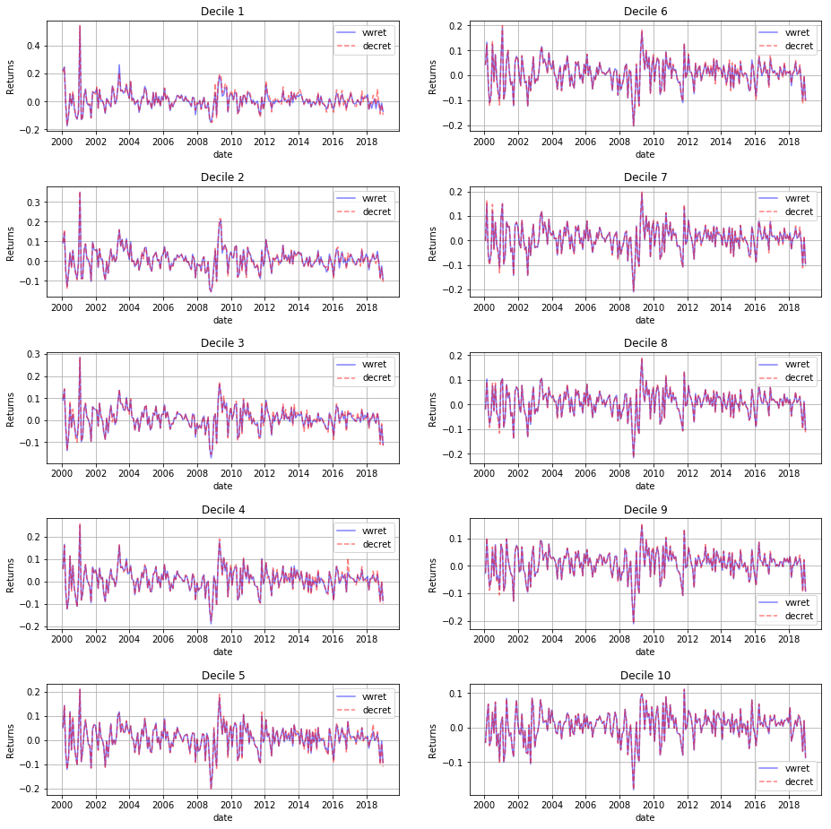

```python
import matplotlib.pyplot as plt

plt.figure()
for i in range(5):
    for j in range(2):
        plt.subplot2grid((5,2), (i,j))
        plt.plot(decile_returns[decile_returns['decile']==i+1+j*5].date, decile_returns[decile_returns['decile']==i+1+j*5].vwret, 'b', alpha=0.5)
        plt.plot(decile_returns[decile_returns['decile']==i+1+j*5].date, decile_returns[decile_returns['decile']==i+1+j*5].decret, 'r--', alpha=0.5)
        plt.xlabel('date')
        plt.ylabel('Returns')
        plt.legend(['vwret', 'decret'])
        plt.title('Decile ' + str(i+1+j*5))
        plt.grid(True)

plt.subplots_adjust(top=3, bottom=0, left=0, right=2, hspace=0.5,
                 wspace=0.2)
plt.show()
```

## Case 2. Size Portfolios for Common Stocks Using NYSE Breakpoints

This program has been developed to calculate size portfolios for common stocks using NYSE size breakpoints. Graphs comparing these calculated monthly value-weighted returns and CRSP portfolio returns are also available for review.

### Background

This program calculates size portfolios for common stocks in CRSP. It computes monthly value-weighted returns per each decile and portfolios are rebalanced quarterly. Returns are weighted by the market capitalization of securities at the end of the previous month. This program uses NYSE securities to create size-decile breakpoints.

```python
##########################################
# Size Portfolio for Common Stocks       #
# Using NYSE Breakpoints                 #
# Sep 2019                               #
##########################################

import pandas as pd
import numpy as np
import datetime as dt
import wrds
from dateutil.relativedelta import *
from pandas.tseries.offsets import *

###################
# Connect to WRDS #
###################
conn=wrds.Connection()

########################
# CRSP Data Collection #
########################
# Code Similar to CRSPMERGE
crsp_m = conn.raw_sql("""
                      select a.permno, a.date,
                      b.shrcd, b.exchcd,
                      a.ret, a.vol, a.shrout, a.prc, a.cfacpr, a.cfacshr
                      from crsp.msf as a
                      left join crsp.msenames as b
                      on a.permno=b.permno
                      and b.namedt<=a.date
                      and a.date<=b.nameendt
                      where a.date between '01/01/1991' and '12/31/2018'
                      and b.shrcd between 10 and 11
                      """, date_cols=['date'])

# change variable format to int
crsp_m[['permno', 'shrcd', 'exchcd']]=crsp_m[['permno', 'shrcd', 'exchcd']].astype(int)
# line up date to end of month
crsp_m['jdate']=crsp_m['date']+MonthEnd(0)

# add delisting return
dlret = conn.raw_sql("""
                     select permno, dlret, dlstdt
                     from crsp.msedelist
                     """, date_cols=['dlstdt'])
dlret['permno']=dlret['permno'].astype(int)
dlret['jdate']=dlret['dlstdt']+MonthEnd(0)

# merge dlret to get total return
crsp = pd.merge(crsp_m, dlret, how='left',on=['permno','jdate'])
crsp['dlret']=crsp['dlret'].fillna(0)
crsp['ret']=crsp['ret'].fillna(0)
crsp['totret']=(1+crsp['ret'])*(1+crsp['dlret'])-1

# calculate lag size
crsp['month']=crsp['date'].dt.month
crsp['exchcd']=crsp['exchcd'].abs()
crsp['size']=crsp['prc'].abs()*crsp['shrout']
crsp = crsp.sort_values(['permno', 'date'])
crsp['size_lag'] = crsp.groupby('permno')['size'].shift(1)

# if first month of a permno, size_lag is size/(1+ret)
crsp['size_lag'] = np.where(crsp['size_lag'].isna(), \
crsp['size']/(1+crsp['ret']), crsp['size_lag'])

############################
# Output Intermediate Data #
############################
# all quarterly observations
q1 = crsp[(crsp['month']==3)|(crsp['month']==6)|(crsp['month']==9)|(crsp['month']==12)]
q1 = q1[['date', 'jdate','permno', 'exchcd', 'size']]

# quarterly NYSE observations
nyse_q = q1[q1['exchcd']==1]

# all monthly observations
m1 = crsp[['date','jdate','permno','size_lag', 'totret']]
m1['port_date']=m1['jdate']+QuarterEnd(-1)

# Calculate NYSE Decile Break Point
nyse_bp=nyse_q.groupby(['jdate'])['size']\
.describe(percentiles=[0, .1, .2, .3, .4,.5,.6,.7,.8,.9, 1]).reset_index()

nyse_bp=nyse_bp.rename(columns={'0%':'pct0', '10%':'pct10', '20%':'pct20','30%':'pct30', \
                                '40%':'pct40','50%':'pct50','60%':'pct60','70%':'pct70',\
                                '80%':'pct80','90%':'pct90','100%':'pct100'})

nyse_bp = nyse_bp.drop(['count','mean','std','min','max'], axis=1)
nyse_bp['qtrdate'] = nyse_bp['jdate']+QuarterEnd(0)

# assign stocks to portfolios at each quarter end
qtr_decile = pd.merge(q1, nyse_bp, how='left', left_on=['jdate'], right_on=['qtrdate'])
qtr_decile = qtr_decile.drop(['jdate_x','jdate_y'], axis=1)

# function to assign size group
def sizegrp(row):
    if   (row['pct0']<=row['size']<row['pct10']):
        group=1
    elif (row['pct10']<=row['size']<row['pct20']):
        group=2
    elif (row['pct20']<=row['size']<row['pct30']):
        group=3
    elif (row['pct30']<=row['size']<row['pct40']):
        group=4
    elif (row['pct40']<=row['size']<row['pct50']):
        group=5
    elif (row['pct50']<=row['size']<row['pct60']):
        group=6
    elif (row['pct60']<=row['size']<row['pct70']):
        group=7
    elif (row['pct70']<=row['size']<row['pct80']):
        group=8
    elif (row['pct80']<=row['size']<row['pct90']):
        group=9
    elif (row['pct90']<=row['size']<=row['pct100']):
        group=10
    else:
        group=np.nan
    return pd.Series({'permno':row['permno'], 'date':row['date'], 'exchcd':row['exchcd'], \
                      'qtrdate':row['qtrdate'], 'size': row['size'], 'group': group})

qtr_decile=qtr_decile.apply(sizegrp, axis=1)

# label NYSE listed stocks
qtr_decile['nyse_listed']=np.where(qtr_decile['exchcd']==1, 'yes', 'no')

# summary table for frequency count
summ_table = qtr_decile.groupby(['qtrdate', 'group','nyse_listed'])['permno']\
.count().reset_index()
freq_table=pd.pivot_table(summ_table, index=['qtrdate'],\
 values='permno', columns=['nyse_listed','group'])
freq_table.head(10)

###########################################
# Establish Size Group for Monthly Record #
###########################################

m_group = pd.merge(m1[['permno','date','totret','size_lag','port_date']], \
                   qtr_decile[['permno','qtrdate','group']], \
                   how='left', left_on=['permno', 'port_date'], right_on=['permno','qtrdate'])
m_group=m_group[m_group['group'].notna()].drop(['qtrdate','port_date'], axis=1)

# Calculate Monthly Weighted Average Returns by Size Group
m_group =m_group.sort_values(['group', 'date'])

# function to calculate value weighted return
def wavg(group, avg_name, weight_name):
    d = group[avg_name]
    w = group[weight_name]
    try:
        return (d * w).sum() / w.sum()
    except ZeroDivisionError:
        return np.nan

# value-weigthed return
dec_ret=m_group.groupby(['group','date']).\
apply(wavg, 'totret','size_lag').to_frame().reset_index().\
rename(columns={0: 'decile_ret'})

###########################
# Compare with CRSP Index #
# from CRSP MSHISTQ       #
###########################
crsp_ix = conn.raw_sql("""
                      select caldt, totret as crsp_ret, prtnam
                      from crsp.mhistq
                      where prtnam in ('1','2','3','4','5','6','7','8','9','10')
                      and caldt>='01/01/1991'""", date_cols=['caldt'])

crsp_ix['prtnam']=crsp_ix['prtnam'].astype(int)
crsp_ix['group'] = 11-crsp_ix['prtnam']

dec_ret_comp=pd.merge(dec_ret, crsp_ix, how='left', \
                      left_on=['date', 'group'], right_on=['caldt','group'])

###################
# End of Program  #
###################
```

```
Loading library list...
Done
```

### Output Discussion

NYSE Size Breakpoints by Date

```python
nyse_bp.head(10)
```

|  | jdate | pct0 | pct10 | pct20 | pct30 | pct40 | pct50 | pct60 | pct70 | pct80 | pct90 | pct100 | qtrdate |
| --- | --- | --- | --- | --- | --- | --- | --- | --- | --- | --- | --- | --- | --- |
| 0 | 1991-03-31 | 712.578125 | 39029.5500 | 88848.150 | 173578.7250 | 277317.600 | 475664.0000 | 784703.925 | 1.293075e+06 | 2231036.200 | 4.821036e+06 | 7.283250e+07 | 1991-03-31 |
| 1 | 1991-06-30 | 696.375000 | 39850.1250 | 90309.650 | 177875.8000 | 290333.250 | 489238.2500 | 776019.825 | 1.255427e+06 | 2193093.800 | 4.654258e+06 | 7.235086e+07 | 1991-06-30 |
| 2 | 1991-09-30 | 464.250000 | 42337.0500 | 94381.800 | 176571.5250 | 322494.800 | 530411.6250 | 825675.650 | 1.327521e+06 | 2397783.525 | 4.835150e+06 | 7.400836e+07 | 1991-09-30 |
| 3 | 1991-12-31 | 641.062500 | 41084.1625 | 99293.250 | 190069.2000 | 326515.725 | 547397.6250 | 870568.200 | 1.416324e+06 | 2501737.125 | 5.148963e+06 | 7.565302e+07 | 1991-12-31 |
| 4 | 1992-03-31 | 1882.187500 | 55690.2750 | 121321.300 | 208055.7500 | 341294.750 | 560859.7500 | 878075.125 | 1.397382e+06 | 2454777.900 | 5.120722e+06 | 6.986604e+07 | 1992-03-31 |
| 5 | 1992-06-30 | 941.093750 | 49829.6125 | 108026.600 | 192044.7000 | 322361.600 | 509145.1250 | 844333.775 | 1.308141e+06 | 2473299.950 | 4.982580e+06 | 7.684875e+07 | 1992-06-30 |
| 6 | 1992-09-30 | 752.875000 | 51495.7500 | 107099.925 | 199249.0250 | 334247.200 | 531365.6250 | 874341.000 | 1.339283e+06 | 2542818.025 | 5.114512e+06 | 7.929973e+07 | 1992-09-30 |
| 7 | 1992-12-31 | 672.312500 | 58186.0875 | 122974.350 | 230278.6250 | 366305.950 | 586234.6875 | 953735.300 | 1.448601e+06 | 2710006.900 | 5.319399e+06 | 7.588443e+07 | 1992-12-31 |
| 8 | 1993-03-31 | 1196.437500 | 62754.0000 | 139109.700 | 243911.7000 | 392867.100 | 608600.8750 | 986508.825 | 1.501014e+06 | 2820294.750 | 5.460299e+06 | 8.212725e+07 | 1993-03-31 |
| 9 | 1993-06-30 | 697.921875 | 59773.5250 | 141763.125 | 252385.0875 | 406721.475 | 623533.1875 | 998844.075 | 1.533805e+06 | 2825421.300 | 5.309690e+06 | 8.468202e+07 | 1993-06-30 |

Frequency of PERMNO's by DATE, NYSE SIZE-DECILE, for NYSE Stocks and Non NYSE Stocks

```python
freq_table.head(10)
```

| nyse_listed group qtrdate | no 1.0 | no 2.0 | no 3.0 | no 4.0 | no 5.0 | no 6.0 | no 7.0 | no 8.0 | no 9.0 | no 10.0 | yes 1.0 | yes 2.0 | yes 3.0 | yes 4.0 | yes 5.0 | yes 6.0 | yes 7.0 | yes 8.0 | yes 9.0 | yes 10.0 |
| --- | --- | --- | --- | --- | --- | --- | --- | --- | --- | --- | --- | --- | --- | --- | --- | --- | --- | --- | --- | --- |
| 1991-03-31 | 2735 | 604 | 380 | 204 | 147 | 69 | 60 | 31 | 14 | 5 | 133 | 133 | 133 | 133 | 132 | 133 | 133 | 133 | 133 | 133 |
| 1991-06-30 | 2711 | 652 | 393 | 210 | 126 | 78 | 49 | 35 | 13 | 5 | 136 | 135 | 135 | 136 | 135 | 135 | 136 | 135 | 135 | 136 |
| 1991-09-30 | 2717 | 623 | 406 | 255 | 132 | 81 | 51 | 37 | 13 | 6 | 136 | 136 | 136 | 136 | 136 | 136 | 136 | 136 | 136 | 136 |
| 1991-12-31 | 2638 | 658 | 444 | 237 | 141 | 93 | 40 | 43 | 16 | 7 | 139 | 138 | 138 | 139 | 138 | 138 | 139 | 138 | 138 | 139 |
| 1992-03-31 | 2633 | 693 | 351 | 223 | 151 | 87 | 47 | 35 | 16 | 7 | 142 | 141 | 142 | 141 | 141 | 142 | 141 | 142 | 141 | 142 |
| 1992-06-30 | 2700 | 711 | 397 | 226 | 132 | 88 | 45 | 34 | 16 | 7 | 145 | 144 | 144 | 144 | 144 | 144 | 144 | 144 | 144 | 145 |
| 1992-09-30 | 2709 | 658 | 427 | 229 | 124 | 89 | 42 | 36 | 17 | 7 | 146 | 146 | 146 | 145 | 146 | 146 | 145 | 146 | 146 | 146 |
| 1992-12-31 | 2684 | 693 | 438 | 217 | 143 | 90 | 52 | 38 | 17 | 8 | 149 | 148 | 148 | 149 | 148 | 148 | 149 | 148 | 148 | 149 |
| 1993-03-31 | 2755 | 743 | 389 | 217 | 120 | 82 | 47 | 44 | 15 | 6 | 151 | 151 | 151 | 151 | 150 | 151 | 151 | 151 | 151 | 151 |
| 1993-06-30 | 2742 | 864 | 400 | 225 | 105 | 97 | 46 | 45 | 13 | 8 | 153 | 153 | 153 | 152 | 153 | 153 | 152 | 153 | 153 | 153 |

Sample cases from datasets M1_PLUS_GROUP

```python
m_group.sort_values(['permno', 'date']).head(10)
```

|  | permno | date | totret | size_lag | group |
| --- | --- | --- | --- | --- | --- |
| 3 | 10001 | 1991-04-30 | 0.039474 | 10013.000 | 1.0 |
| 4 | 10001 | 1991-05-31 | 0.000000 | 10408.250 | 1.0 |
| 5 | 10001 | 1991-06-28 | 0.078481 | 10408.250 | 1.0 |
| 6 | 10001 | 1991-07-31 | -0.035714 | 11266.500 | 1.0 |
| 7 | 10001 | 1991-08-30 | 0.135802 | 10864.125 | 1.0 |
| 8 | 10001 | 1991-09-30 | 0.013043 | 12339.500 | 1.0 |
| 9 | 10001 | 1991-10-31 | 0.130435 | 12339.500 | 1.0 |
| 10 | 10001 | 1991-11-29 | 0.134615 | 13949.000 | 1.0 |
| 11 | 10001 | 1991-12-31 | -0.006780 | 15826.750 | 1.0 |
| 12 | 10001 | 1992-01-31 | -0.051724 | 15587.500 | 1.0 |

Decile returns Records, plus CRSP decile returns

```python
dec_ret_comp.head(10)
```

|  | group | date | decile_ret | caldt | crsp_ret | prtnam |
| --- | --- | --- | --- | --- | --- | --- |
| 0 | 1 | 1991-04-30 | 0.038607 | 1991-04-30 | 0.028176 | 10 |
| 1 | 1 | 1991-05-31 | 0.020886 | 1991-05-31 | 0.023484 | 10 |
| 2 | 1 | 1991-06-28 | -0.032981 | 1991-06-28 | -0.035897 | 10 |
| 3 | 1 | 1991-07-31 | 0.023860 | 1991-07-31 | 0.023063 | 10 |
| 4 | 1 | 1991-08-30 | 0.020333 | 1991-08-30 | 0.015702 | 10 |
| 5 | 1 | 1991-09-30 | 0.007573 | 1991-09-30 | 0.003264 | 10 |
| 6 | 1 | 1991-10-31 | 0.016355 | 1991-10-31 | 0.008265 | 10 |
| 7 | 1 | 1991-11-29 | -0.016229 | 1991-11-29 | -0.027466 | 10 |
| 8 | 1 | 1991-12-31 | 0.016474 | 1991-12-31 | 0.018158 | 10 |
| 9 | 1 | 1992-01-31 | 0.179653 | 1992-01-31 | 0.185113 | 10 |

The figure below plots the comparison between value-weighted decile returns calculated from the Python code against the decile returns obtained from CRSP.MHISTQ dataset.

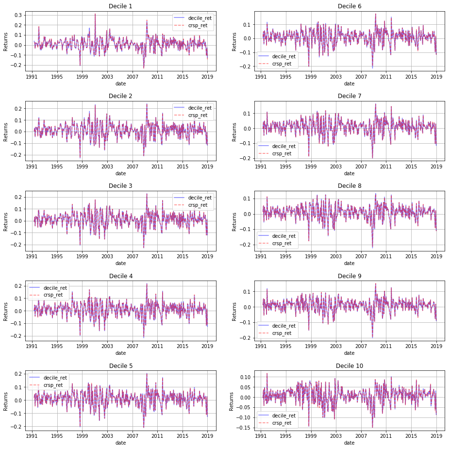

```python
plt.figure()
for i in range(5):
    for j in range(2):
        plt.subplot2grid((5,2), (i,j))
        plt.plot(dec_ret_comp[dec_ret_comp['group']==i+1+j*5].date, dec_ret_comp[dec_ret_comp['group']==i+1+j*5].decile_ret, 'b', alpha=0.5)
        plt.plot(dec_ret_comp[dec_ret_comp['group']==i+1+j*5].date, dec_ret_comp[dec_ret_comp['group']==i+1+j*5].crsp_ret, 'r--', alpha=0.5)
        plt.xlabel('date')
        plt.ylabel('Returns')
        plt.legend(['decile_ret', 'crsp_ret'])
        plt.title('Decile ' + str(i+1+j*5))
        plt.grid(True)

plt.subplots_adjust(top=3, bottom=0, left=0, right=2, hspace=0.5,
                 wspace=0.2)
plt.show()
```